# CRD: Assumptions & Diagnostics

Checking Assumptions and Diagnosing Problems

Dr. Samuel B Fernandes

2026-01-01

## Learning Objectives

By the end of this lecture, you should be able to:

- Create and interpret diagnostic plots: Q-Q plot, residual vs fitted, scale-location
- Conduct formal tests for assumptions: Shapiro-Wilk test, Levene’s test

# ANOVA Assumptions Explained

## Assumption 1: Normality

**What it means:**

- Errors (residuals) follow a normal distribution
- Not the raw data, but the **residuals** from the model

**Why it matters:**

- F-test relies on normal distribution theory
- Violated → p-values unreliable

**Good news:**

- ANOVA is **robust** to mild non-normality with balanced designs
- Central Limit Theorem helps with larger sample sizes (n > 30 per group)

**Residual** = Observed - Predicted
$$e_{ij} = y_{ij} - \hat{y}_{ij}$$

where $\hat{y}_{ij}$ is the treatment mean for group $i$.

## Assumption 2: Homogeneity of Variance

**What it means:**

- All treatment groups have the same error variance $\sigma^2$
- Also called **homoscedasticity**

**Why it matters:**

- F-test assumes equal variance
- Violated → Some groups have noisier data, biasing comparisons

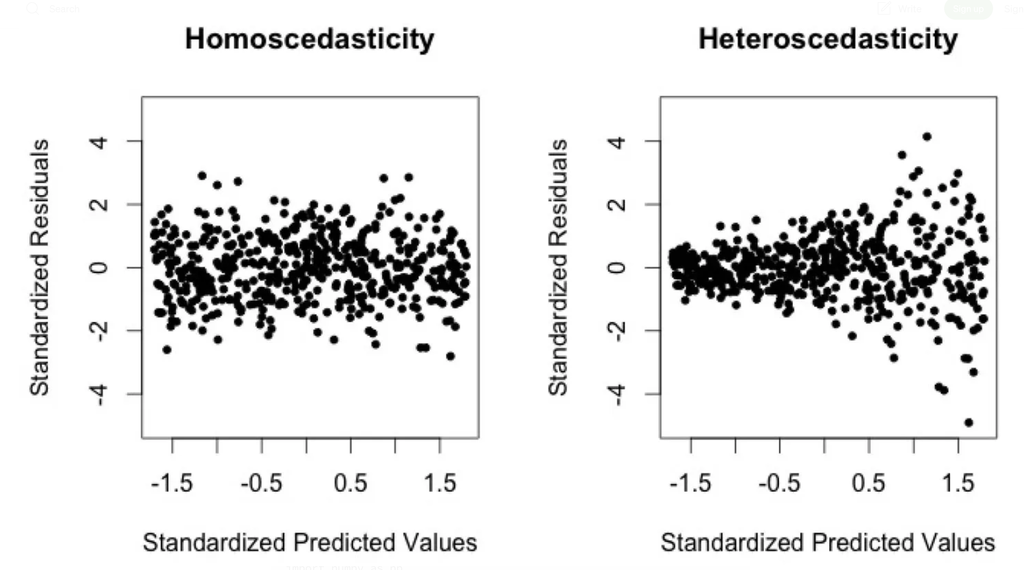

Homoscedasticity vs Heteroscedasticity

## Assumption 3: Independence

**What it means:**

- Each observation is independent—no correlation between errors
- Randomization ensures independence

**Common violations in agriculture:**

- **Spatial correlation:** Adjacent plots influence each other (water runoff, pest movement)
- **Temporal correlation:** Repeated measures on same unit over time
- **Cluster effects:** Animals in same pen more similar than random

**How to prevent:**

- Proper randomization
- Physical separation of units
- Blocking to account for spatial patterns
- Use mixed models for repeated measures (later in course)

# Checking Normality

## The Q-Q Plot

**Quantile-Quantile (Q-Q) Plot:**

- Compares sample quantiles to theoretical normal quantiles
- **Good:** Points fall on diagonal line
- **Bad:** Points deviate systematically

**Interpretation guide:**

- **Light tails:** Flatter than line at ends
- **Heavy tails:** Steeper than line at ends
- **Skewness:** Curve away from line

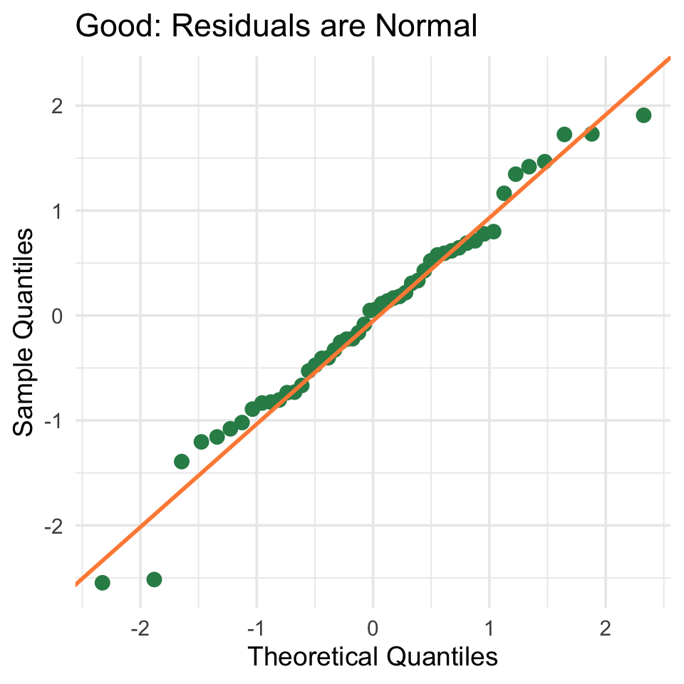

Figure 1: Good Q-Q plot: Points follow the line closely

## Q-Q Plot Examples: Good vs Bad

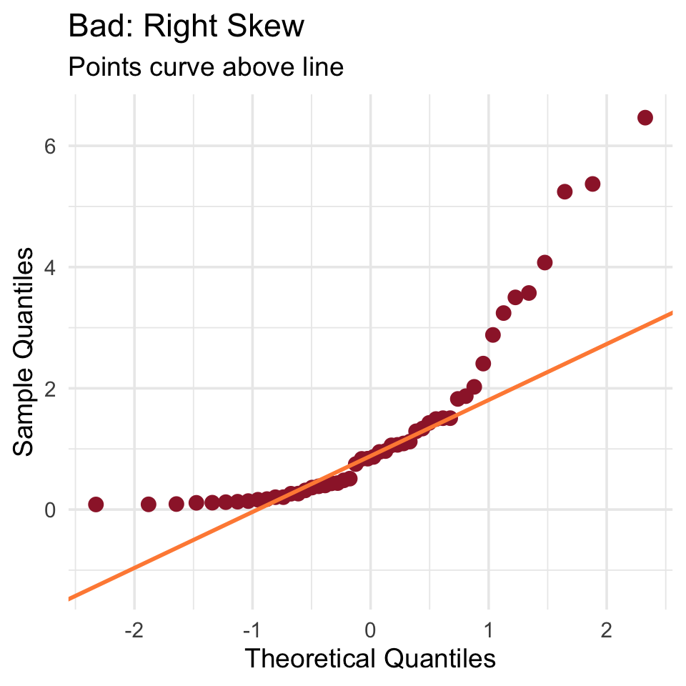

Figure 2: Bad: Right-skewed residuals (transformation needed)

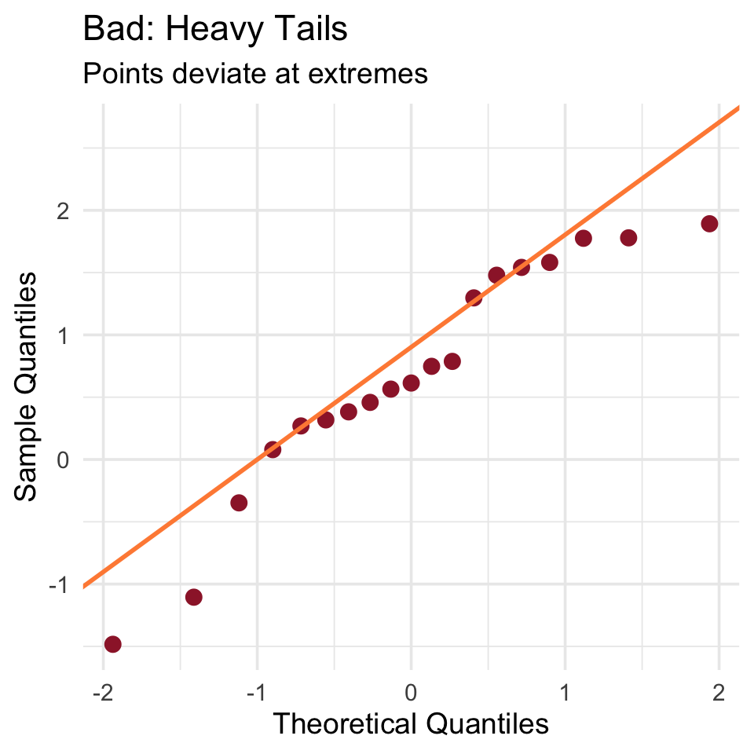

## Shapiro-Wilk Test for Normality

**Formal hypothesis test:**

- $H_0$: Residuals are normally distributed
- $H_a$: Residuals are not normally distributed

```r
# Reload data from Lecture 3
set.seed(2026)
crd_data <- data.frame(
  treatment = rep(c("N0", "N50", "N100", "N150"), each = 6),
  yield = c(
    rnorm(6, 2400, 150), rnorm(6, 2650, 150),
    rnorm(6, 2900, 150), rnorm(6, 2950, 150)
  )
)

# Fit model
model_crd <- lm(yield ~ treatment, data = crd_data)

# Extract residuals
residuals <- resid(model_crd)

# Shapiro-Wilk test
shapiro.test(residuals)
```

```
#>
#>  Shapiro-Wilk normality test
#>
#> data:  residuals
#> W = 0.94396, p-value = 0.1998
```

**Interpretation:**

- p = 0.1998 > 0.05 → Fail to reject $H_0$
- No evidence of non-normality
- Safe to proceed with ANOVA

# Checking Homogeneity of Variance

## Residual vs Fitted Plot

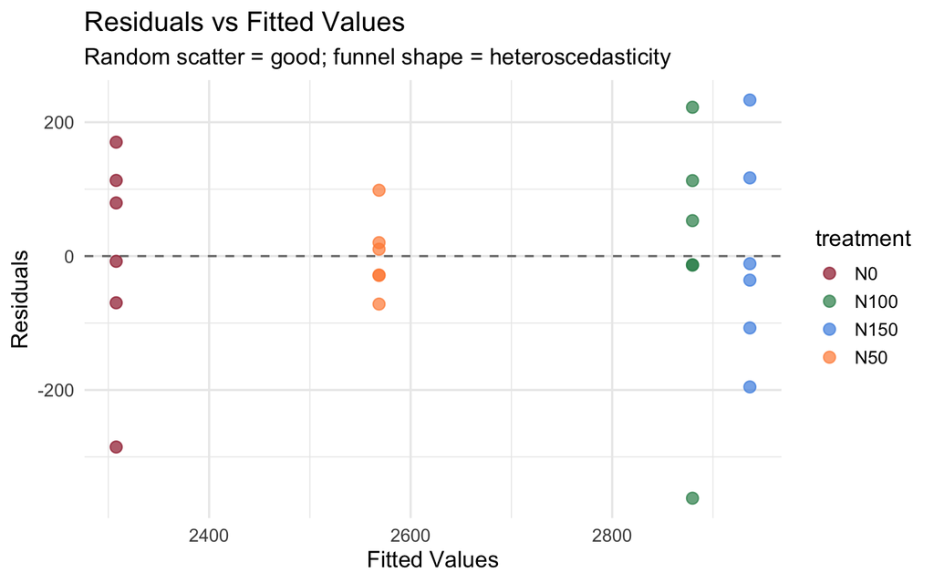

Figure 4: Residual vs fitted plot to check homoscedasticity

```r
library(ggplot2)

# Create diagnostic data
diag_data <- data.frame(
  fitted = fitted(model_crd),
  residuals = resid(model_crd),
  treatment = crd_data$treatment
)

ggplot(diag_data, aes(x = fitted, y = residuals)) +
  geom_hline(yintercept = 0, linetype = "dashed", color = "gray50") +
  geom_point(aes(color = treatment), size = 3, alpha = 0.7) +
  scale_color_manual(values = c("N0" = "#9D2235",
                                 "N50" = "#FF8C42",
                                 "N100" = "#2E8B57",
                                 "N150" = "#4A90E2")) +
  labs(
    title = "Residuals vs Fitted Values",
    subtitle = "Random scatter = good; funnel shape = heteroscedasticity",
    x = "Fitted Values",
    y = "Residuals"
  ) +
  theme_minimal(base_size = 14)
```

**What to look for:**

- **Good:** Random scatter around zero, no pattern
- **Bad:** Funnel shape (variance increases), systematic trends

## Scale-Location Plot

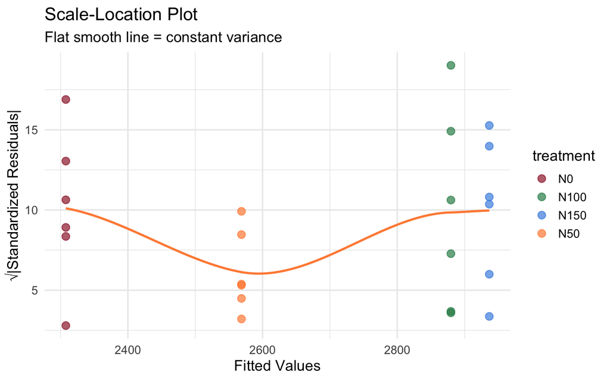

Figure 5: Scale-location plot: Checking for heteroscedasticity

```r
diag_data <- diag_data |>
  dplyr::mutate(sqrt_abs_resid = sqrt(abs(residuals)))

ggplot(diag_data, aes(x = fitted, y = sqrt_abs_resid)) +
  geom_point(aes(color = treatment), size = 3, alpha = 0.7) +
  geom_smooth(method = "loess", se = FALSE, color = "#FF8C42", linewidth = 1) +
  scale_color_manual(values = c("N0" = "#9D2235",
                                 "N50" = "#FF8C42",
                                 "N100" = "#2E8B57",
                                 "N150" = "#4A90E2")) +
  labs(
    title = "Scale-Location Plot",
    subtitle = "Flat smooth line = constant variance",
    x = "Fitted Values",
    y = "√|Standardized Residuals|"
  ) +
  theme_minimal(base_size = 14)
```

**Interpretation:**

- Smooth line should be roughly horizontal
- Upward or downward trend → heteroscedasticity

## Levene’s Test for Equal Variance

**Formal hypothesis test:**

- $H_0: \sigma_1^2 = \sigma_2^2 = \cdots = \sigma_t^2$ (Equal variances)
- $H_a$: At least one variance differs

```r
library(car)

# Levene's test
leveneTest(yield ~ treatment, data = crd_data)
```

```
#> Levene's Test for Homogeneity of Variance (center = median)
#>       Df F value Pr(>F)
#> group  3  0.9206 0.4489
#>       20
```

**Interpretation:**

- p = 0.4489 > 0.05 → Fail to reject $H_0$
- No evidence of unequal variances
- Homoscedasticity assumption satisfied

**Caution**

**Warning:** Like Shapiro-Wilk, Levene’s test is sensitive to sample size. Use plots + test together.

# When Assumptions Fail: Transformations

## Common Data Transformations

**Transformation Table:**

| Problem | Transformation |
| --- | --- |
| Right skew | `log(y)` or `sqrt(y)` |
| Count data | `sqrt(y + 0.5)` |
| Proportion data | `arcsin(sqrt(y))` |
| Heteroscedasticity | `log(y)` often helps |
| Don’t know | Box-Cox finds optimal |

**When to transform:**

**Remember:** Transform → Analyze → Interpret on original scale (back-transform means if needed)

## Box-Cox Transformation

**Finds optimal power transformation:**
$$y^{(\lambda)} = \begin{cases}
\frac{y^\lambda - 1}{\lambda} & \text{if } \lambda \neq 0 \\
\log(y) & \text{if } \lambda = 0
\end{cases}$$

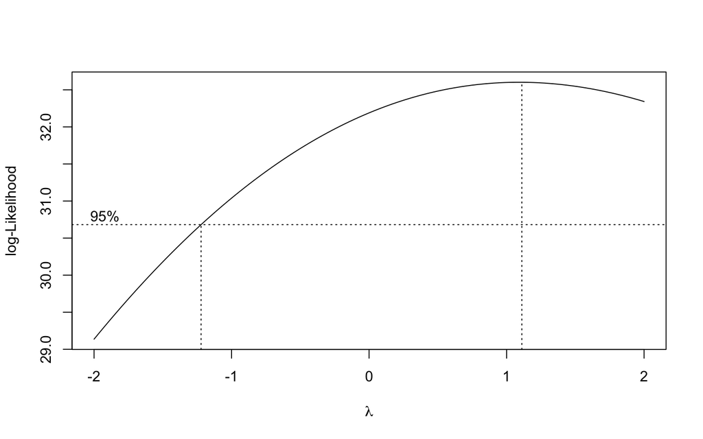

Figure 6: Box-Cox transformation plot: Optimal λ near 1 (no transformation needed)

```r
library(MASS)

# Box-Cox on CRD model
bc <- boxcox(model_crd, lambda = seq(-2, 2, 0.1))
```

```r
# Extract optimal lambda
lambda_optimal <- bc$x[which.max(bc$y)]

cat("Optimal λ =", round(lambda_optimal, 2))
```

```
#> Optimal λ = 1.11
```

**Interpretation:**

- λ = 1 → No transformation
- λ = 0.5 → Square root
- λ = 0 → Log
- λ = -1 → Reciprocal

## Transformation Example: Right-Skewed Data

```r
# Simulate right-skewed yield data (common in real trials)
set.seed(2026)
skewed_data <- data.frame(
  treatment = rep(c("A", "B", "C"), each = 10),
  yield = c(
    exp(rnorm(10, 5, 0.5)),    # Treatment A
    exp(rnorm(10, 7, 0.5)),  # Treatment B
    exp(rnorm(10, 9, 0.5))   # Treatment C
  )
)

# Fit model
model_skewed <- lm(yield ~ treatment, data = skewed_data)

# Check normality
shapiro.test(resid(model_skewed))
```

```
#>
#>  Shapiro-Wilk normality test
#>
#> data:  resid(model_skewed)
#> W = 0.83621, p-value = 0.0003231
```

**Result:** p = 0.0.0003231 < 0.05 → Significant non-normality

## Applying Log Transformation

```r
# Log transformation
skewed_data$log_yield <- log(skewed_data$yield)

# Fit model on transformed data
model_log <- lm(log_yield ~ treatment, data = skewed_data)

# Check normality again
shapiro.test(resid(model_log))
```

```
#>
#>  Shapiro-Wilk normality test
#>
#> data:  resid(model_log)
#> W = 0.94608, p-value = 0.1326
```

**Result:** p = 0.1326 > 0.05 → Normality assumption now satisfied!

**Re-run ANOVA:**

```r
library(car)
#another option for ANOVA table
Anova(model_log)
```

```
#> Anova Table (Type II tests)
#>
#> Response: log_yield
#>            Sum Sq Df F value    Pr(>F)
#> treatment 104.720  2  202.49 < 2.2e-16 ***
#> Residuals   6.982 27
#> ---
#> Signif. codes:  0 '***' 0.001 '**' 0.01 '*' 0.05 '.' 0.1 ' ' 1
```

**Transformation fixed the violation.** Now interpret results on log scale or back-transform means for reporting.

## Before vs After Transformation

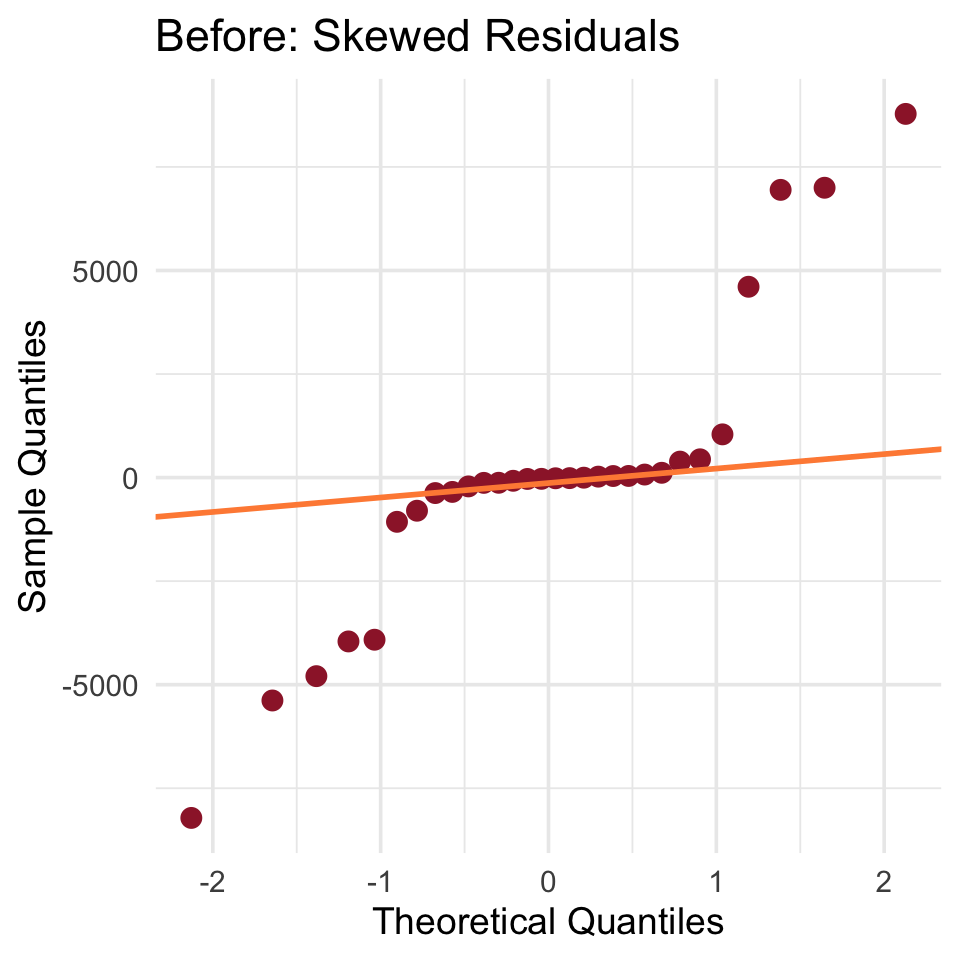

Figure 7: Q-Q plot BEFORE log transformation

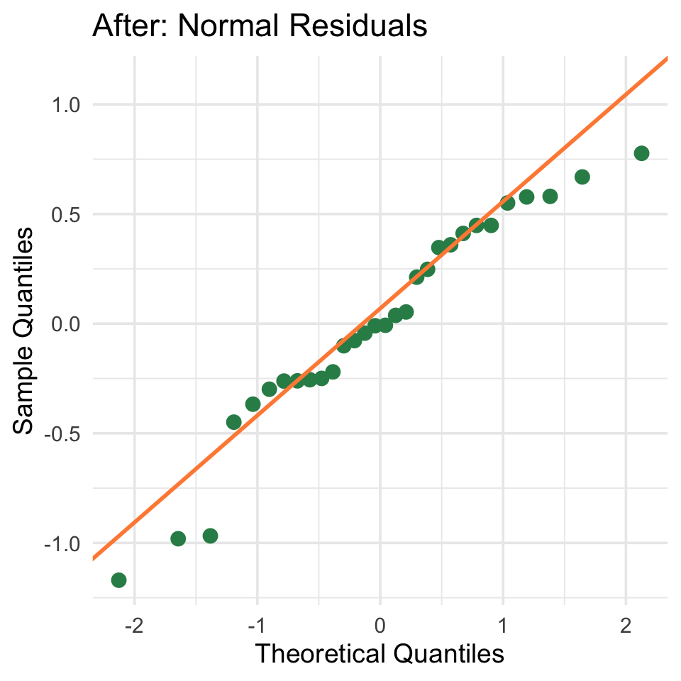

Figure 8: Q-Q plot AFTER log transformation

# Your Turn Activity

## Diagnose This Dataset

**Scenario:**  
A food scientist tests 4 pasteurization temperatures on bacterial count (CFU/mL) in milk samples. CRD with 6 samples per temperature.

**Data provided:**

```
#>   temperature cfu
#> 1         60C 113
#> 2         60C 133
#> 3         60C 101
#> 4         60C 121
#> 5         60C 138
#> 6         60C 125
#> 7         65C  68
#> 8         65C  64
```

**Questions (3 minutes):**

1. Fit ANOVA model
2. Check Q-Q plot and residual plot
3. Is transformation needed? If so, which one?
4. Share your diagnosis with a neighbor

# Summary & Key Takeaways

- **Transformations** fix many violations: log, sqrt, Box-Cox

## What We Learned Today

- **Three ANOVA assumptions:** Normality, homogeneity of variance, independence
- **Diagnostic tools:** Q-Q plots, residual plots, Shapiro-Wilk, Levene’s test
- **Visual diagnostics** are primary—formal tests are secondary
- **Normality violations** are less serious with balanced designs and large sample sizes
- **Heteroscedasticity** (unequal variances) is more serious—always address it

**Key principle:** Never trust ANOVA results without checking assumptions first!

## Resources

**Textbook:**

- Oehlert (2010), **Chapter 3 and 6 (diagnostics)**: Model diagnostics and transformations

**R Packages:**

- `car`: `leveneTest()`, `qqPlot()`, `Anova()`
- `MASS`: `boxcox()` for transformation selection
- `ggplot2`: Custom diagnostic plots

**Online Resources:**

- Q-Q plot interpretation: [link](https://data.library.virginia.edu/understanding-q-q-plots/)